# 1. Business Problem

### 4.5.2. Testing model with best hyper parameters (One Hot Encoding)

```
Log loss : 1.1922970805549726
Number of mis-classified points : 0.424812030075188
-------------------- Confusion matrix --------------------
```

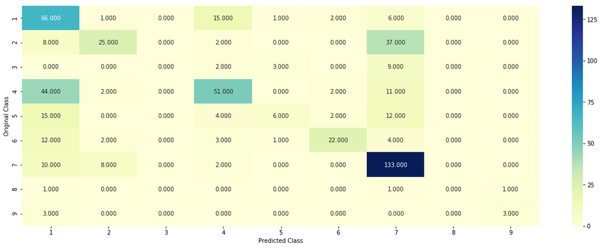

```
-------------------- Precision matrix (Columm Sum=1) --------------------
```

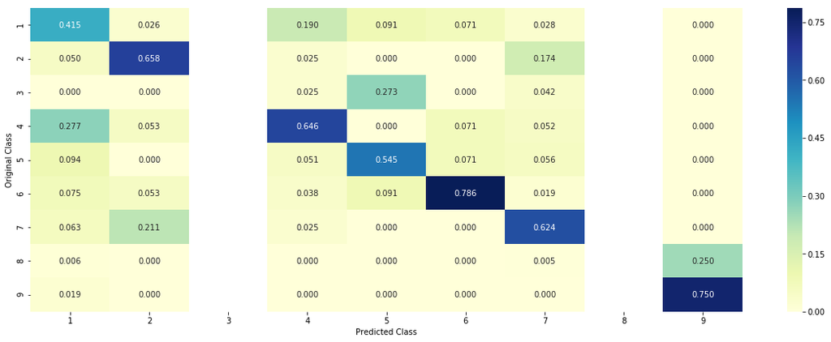

```
-------------------- Recall matrix (Row sum=1) --------------------
```

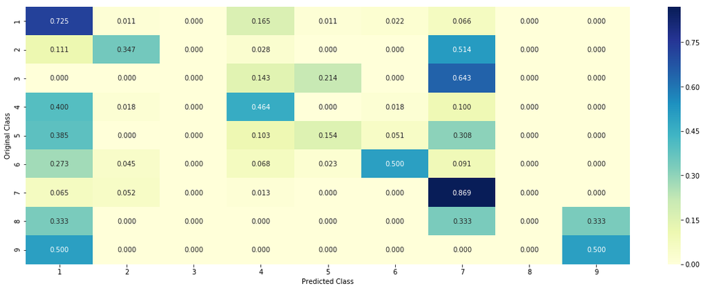

```python
# --------------------------------
# default parameters
# sklearn.ensemble.RandomForestClassifier(n_estimators=10, criterion=’gini’, max_depth=None, min_samples_split=2,
# min_samples_leaf=1, min_weight_fraction_leaf=0.0, max_features=’auto’, max_leaf_nodes=None, min_impurity_decrease=0.0,
# min_impurity_split=None, bootstrap=True, oob_score=False, n_jobs=1, random_state=None, verbose=0, warm_start=False,
# class_weight=None)

# Some of methods of RandomForestClassifier()
# fit(X, y, [sample_weight])	Fit the SVM model according to the given training data.
# predict(X)	Perform classification on samples in X.
# predict_proba (X)	Perform classification on samples in X.

# some of attributes of  RandomForestClassifier()
# feature_importances_ : array of shape = [n_features]
# The feature importances (the higher, the more important the feature).

# --------------------------------
# video link: https://www.appliedaicourse.com/course/applied-ai-course-online/lessons/random-forest-and-their-construction-2/
# --------------------------------

clf = RandomForestClassifier(n_estimators=alpha[int(best_alpha/2)], criterion='gini', max_depth=max_depth[int(best_alpha%2)], random_state=42, n_jobs=-1)
rfmp=predict_and_plot_confusion_matrix(train_x_onehotCoding, train_y,cv_x_onehotCoding,cv_y, clf)
```

### 4.5.3. Feature Importance

#### 4.5.3.1. Correctly Classified point

```python
# test_point_index = 10
clf = RandomForestClassifier(n_estimators=alpha[int(best_alpha/2)], criterion='gini', max_depth=max_depth[int(best_alpha%2)], random_state=42, n_jobs=-1)
clf.fit(train_x_onehotCoding, train_y)
sig_clf = CalibratedClassifierCV(clf, method="sigmoid")
sig_clf.fit(train_x_onehotCoding, train_y)

test_point_index = 1
no_feature = 100
predicted_cls = sig_clf.predict(test_x_onehotCoding[test_point_index])
print("Predicted Class :", predicted_cls[0])
print("Predicted Class Probabilities:", np.round(sig_clf.predict_proba(test_x_onehotCoding[test_point_index]),4))
print("Actual Class :", test_y[test_point_index])
indices = np.argsort(-clf.feature_importances_)
print("-"*50)
get_impfeature_names(indices[:no_feature], test_df['TEXT'].iloc[test_point_index],test_df['Gene'].iloc[test_point_index],test_df['Variation'].iloc[test_point_index], no_feature)
```

```
Predicted Class : 7
Predicted Class Probabilities: [[0.0923 0.1392 0.0291 0.1119 0.0549 0.043  0.4938 0.0102 0.0256]]
Actual Class : 7
--------------------------------------------------
0 Text feature [activating] present in test data point [True]
1 Text feature [kinase] present in test data point [True]
3 Text feature [suppressor] present in test data point [True]
4 Text feature [inhibitors] present in test data point [True]
5 Text feature [activation] present in test data point [True]
6 Text feature [constitutive] present in test data point [True]
7 Text feature [phosphorylation] present in test data point [True]
8 Text feature [function] present in test data point [True]
9 Text feature [loss] present in test data point [True]
10 Text feature [treatment] present in test data point [True]
11 Text feature [missense] present in test data point [True]
```

[output cut: 48 more lines]

```python
test_point_index = 100
no_feature = 100
predicted_cls = sig_clf.predict(test_x_onehotCoding[test_point_index])
print("Predicted Class :", predicted_cls[0])
print("Predicted Class Probabilities:", np.round(sig_clf.predict_proba(test_x_onehotCoding[test_point_index]),4))
print("Actuall Class :", test_y[test_point_index])
indices = np.argsort(-clf.feature_importances_)
print("-"*50)
get_impfeature_names(indices[:no_feature], test_df['TEXT'].iloc[test_point_index],test_df['Gene'].iloc[test_point_index],test_df['Variation'].iloc[test_point_index], no_feature)
```

```
Predicted Class : 7
Predicted Class Probabilities: [[0.1151 0.1128 0.0214 0.1567 0.0526 0.0493 0.4787 0.0061 0.0072]]
Actuall Class : 7
--------------------------------------------------
0 Text feature [activating] present in test data point [True]
3 Text feature [suppressor] present in test data point [True]
4 Text feature [inhibitors] present in test data point [True]
5 Text feature [activation] present in test data point [True]
6 Text feature [constitutive] present in test data point [True]
7 Text feature [phosphorylation] present in test data point [True]
8 Text feature [function] present in test data point [True]
9 Text feature [loss] present in test data point [True]
10 Text feature [treatment] present in test data point [True]
11 Text feature [missense] present in test data point [True]
12 Text feature [activated] present in test data point [True]
```

[output cut: 48 more lines]

### 4.5.3. Hyper paramter tuning (With Response Coding)

```python
# # --------------------------------
# # default parameters
# # sklearn.ensemble.RandomForestClassifier(n_estimators=10, criterion=’gini’, max_depth=None, min_samples_split=2,
# # min_samples_leaf=1, min_weight_fraction_leaf=0.0, max_features=’auto’, max_leaf_nodes=None, min_impurity_decrease=0.0,
# # min_impurity_split=None, bootstrap=True, oob_score=False, n_jobs=1, random_state=None, verbose=0, warm_start=False,
# # class_weight=None)

# # Some of methods of RandomForestClassifier()
# # fit(X, y, [sample_weight])	Fit the SVM model according to the given training data.
# # predict(X)	Perform classification on samples in X.
# # predict_proba (X)	Perform classification on samples in X.

# # some of attributes of  RandomForestClassifier()
# # feature_importances_ : array of shape = [n_features]
# # The feature importances (the higher, the more important the feature).

# # --------------------------------
# # video link: https://www.appliedaicourse.com/course/applied-ai-course-online/lessons/random-forest-and-their-construction-2/
# # --------------------------------


# # find more about CalibratedClassifierCV here at http://scikit-learn.org/stable/modules/generated/sklearn.calibration.CalibratedClassifierCV.html
# # ----------------------------
# # default paramters
# # sklearn.calibration.CalibratedClassifierCV(base_estimator=None, method=’sigmoid’, cv=3)
# #
# # some of the methods of CalibratedClassifierCV()
# # fit(X, y[, sample_weight])	Fit the calibrated model
# # get_params([deep])	Get parameters for this estimator.
# # predict(X)	Predict the target of new samples.
# # predict_proba(X)	Posterior probabilities of classification
# #-------------------------------------
# # video link:
# #-------------------------------------

# alpha = [10,50,100,200,500,1000]
# max_depth = [2,3,5,10]
# cv_log_error_array = []
# for i in alpha:
#     for j in max_depth:
#         print("for n_estimators =", i,"and max depth = ", j)
#         clf = RandomForestClassifier(n_estimators=i, criterion='gini', max_depth=j, random_state=42, n_jobs=-1)
#         clf.fit(train_x_responseCoding, train_y)
#         sig_clf = CalibratedClassifierCV(clf, method="sigmoid")
#         sig_clf.fit(train_x_responseCoding, train_y)
#         sig_clf_probs = sig_clf.predict_proba(cv_x_responseCoding)
#         cv_log_error_array.append(log_loss(cv_y, sig_clf_probs, labels=clf.classes_, eps=1e-15))
#         print("Log Loss :",log_loss(cv_y, sig_clf_probs))
# '''
# fig, ax = plt.subplots()
# features = np.dot(np.array(alpha)[:,None],np.array(max_depth)[None]).ravel()
# ax.plot(features, cv_log_error_array,c='g')
# for i, txt in enumerate(np.round(cv_log_error_array,3)):
#     ax.annotate((alpha[int(i/4)],max_depth[int(i%4)],str(txt)), (features[i],cv_log_error_array[i]))
# plt.grid()
# plt.title("Cross Validation Error for each alpha")
# plt.xlabel("Alpha i's")
# plt.ylabel("Error measure")
# plt.show()
# '''

# best_alpha = np.argmin(cv_log_error_array)
# clf = RandomForestClassifier(n_estimators=alpha[int(best_alpha/4)], criterion='gini', max_depth=max_depth[int(best_alpha%4)], random_state=42, n_jobs=-1)
# clf.fit(train_x_responseCoding, train_y)
# sig_clf = CalibratedClassifierCV(clf, method="sigmoid")
# sig_clf.fit(train_x_responseCoding, train_y)

# predict_y = sig_clf.predict_proba(train_x_responseCoding)
# print('For values of best alpha = ', alpha[int(best_alpha/4)], "The train log loss is:",log_loss(y_train, predict_y, labels=clf.classes_, eps=1e-15))
# predict_y = sig_clf.predict_proba(cv_x_responseCoding)
# print('For values of best alpha = ', alpha[int(best_alpha/4)], "The cross validation log loss is:",log_loss(y_cv, predict_y, labels=clf.classes_, eps=1e-15))
# predict_y = sig_clf.predict_proba(test_x_responseCoding)
# print('For values of best alpha = ', alpha[int(best_alpha/4)], "The test log loss is:",log_loss(y_test, predict_y, labels=clf.classes_, eps=1e-15))
```

### 4.5.4. Testing model with best hyper parameters (Response Coding)

```python
# # --------------------------------
# # default parameters
# # sklearn.ensemble.RandomForestClassifier(n_estimators=10, criterion=’gini’, max_depth=None, min_samples_split=2,
# # min_samples_leaf=1, min_weight_fraction_leaf=0.0, max_features=’auto’, max_leaf_nodes=None, min_impurity_decrease=0.0,
# # min_impurity_split=None, bootstrap=True, oob_score=False, n_jobs=1, random_state=None, verbose=0, warm_start=False,
# # class_weight=None)

# # Some of methods of RandomForestClassifier()
# # fit(X, y, [sample_weight])	Fit the SVM model according to the given training data.
# # predict(X)	Perform classification on samples in X.
# # predict_proba (X)	Perform classification on samples in X.

# # some of attributes of  RandomForestClassifier()
# # feature_importances_ : array of shape = [n_features]
# # The feature importances (the higher, the more important the feature).

# # --------------------------------
# # video link: https://www.appliedaicourse.com/course/applied-ai-course-online/lessons/random-forest-and-their-construction-2/
# # --------------------------------

# clf = RandomForestClassifier(max_depth=max_depth[int(best_alpha%4)], n_estimators=alpha[int(best_alpha/4)], criterion='gini', max_features='auto',random_state=42)
# predict_and_plot_confusion_matrix(train_x_responseCoding, train_y,cv_x_responseCoding,cv_y, clf)
```

### 4.5.5. Feature Importance

#### 4.5.5.1. Correctly Classified point

```python
# clf = RandomForestClassifier(n_estimators=alpha[int(best_alpha/4)], criterion='gini', max_depth=max_depth[int(best_alpha%4)], random_state=42, n_jobs=-1)
# clf.fit(train_x_responseCoding, train_y)
# sig_clf = CalibratedClassifierCV(clf, method="sigmoid")
# sig_clf.fit(train_x_responseCoding, train_y)


# test_point_index = 1
# no_feature = 27
# predicted_cls = sig_clf.predict(test_x_responseCoding[test_point_index].reshape(1,-1))
# print("Predicted Class :", predicted_cls[0])
# print("Predicted Class Probabilities:", np.round(sig_clf.predict_proba(test_x_responseCoding[test_point_index].reshape(1,-1)),4))
# print("Actual Class :", test_y[test_point_index])
# indices = np.argsort(-clf.feature_importances_)
# print("-"*50)
# for i in indices:
#     if i<9:
#         print("Gene is important feature")
#     elif i<18:
#         print("Variation is important feature")
#     else:
#         print("Text is important feature")
```

#### 4.5.5.2. Incorrectly Classified point

```python
# test_point_index = 100
# predicted_cls = sig_clf.predict(test_x_responseCoding[test_point_index].reshape(1,-1))
# print("Predicted Class :", predicted_cls[0])
# print("Predicted Class Probabilities:", np.round(sig_clf.predict_proba(test_x_responseCoding[test_point_index].reshape(1,-1)),4))
# print("Actual Class :", test_y[test_point_index])
# indices = np.argsort(-clf.feature_importances_)
# print("-"*50)
# for i in indices:
#     if i<9:
#         print("Gene is important feature")
#     elif i<18:
#         print("Variation is important feature")
#     else:
#         print("Text is important feature")
```

## 4.7 Stack the models

### 4.7.1 testing with hyper parameter tuning

```python
# read more about SGDClassifier() at http://scikit-learn.org/stable/modules/generated/sklearn.linear_model.SGDClassifier.html
# ------------------------------
# default parameters
# SGDClassifier(loss=’hinge’, penalty=’l2’, alpha=0.0001, l1_ratio=0.15, fit_intercept=True, max_iter=None, tol=None,
# shuffle=True, verbose=0, epsilon=0.1, n_jobs=1, random_state=None, learning_rate=’optimal’, eta0=0.0, power_t=0.5,
# class_weight=None, warm_start=False, average=False, n_iter=None)

# some of methods
# fit(X, y[, coef_init, intercept_init, …])	Fit linear model with Stochastic Gradient Descent.
# predict(X)	Predict class labels for samples in X.

#-------------------------------
# video link: https://www.appliedaicourse.com/course/applied-ai-course-online/lessons/geometric-intuition-1/
#------------------------------


# read more about support vector machines with linear kernals here http://scikit-learn.org/stable/modules/generated/sklearn.svm.SVC.html
# --------------------------------
# default parameters
# SVC(C=1.0, kernel=’rbf’, degree=3, gamma=’auto’, coef0=0.0, shrinking=True, probability=False, tol=0.001,
# cache_size=200, class_weight=None, verbose=False, max_iter=-1, decision_function_shape=’ovr’, random_state=None)

# Some of methods of SVM()
# fit(X, y, [sample_weight])	Fit the SVM model according to the given training data.
# predict(X)	Perform classification on samples in X.
# --------------------------------
# video link: https://www.appliedaicourse.com/course/applied-ai-course-online/lessons/mathematical-derivation-copy-8/
# --------------------------------


# read more about support vector machines with linear kernals here http://scikit-learn.org/stable/modules/generated/sklearn.ensemble.RandomForestClassifier.html
# --------------------------------
# default parameters
# sklearn.ensemble.RandomForestClassifier(n_estimators=10, criterion=’gini’, max_depth=None, min_samples_split=2,
# min_samples_leaf=1, min_weight_fraction_leaf=0.0, max_features=’auto’, max_leaf_nodes=None, min_impurity_decrease=0.0,
# min_impurity_split=None, bootstrap=True, oob_score=False, n_jobs=1, random_state=None, verbose=0, warm_start=False,
# class_weight=None)

# Some of methods of RandomForestClassifier()
# fit(X, y, [sample_weight])	Fit the SVM model according to the given training data.
# predict(X)	Perform classification on samples in X.
# predict_proba (X)	Perform classification on samples in X.

# some of attributes of  RandomForestClassifier()
# feature_importances_ : array of shape = [n_features]
# The feature importances (the higher, the more important the feature).

# --------------------------------
# video link: https://www.appliedaicourse.com/course/applied-ai-course-online/lessons/random-forest-and-their-construction-2/
# --------------------------------


clf1 = SGDClassifier(alpha=0.001, penalty='l2', loss='log', class_weight='balanced', random_state=0)
clf1.fit(train_x_onehotCoding, train_y)
sig_clf1 = CalibratedClassifierCV(clf1, method="sigmoid")

clf2 = SGDClassifier(alpha=1, penalty='l2', loss='hinge', class_weight='balanced', random_state=0)
clf2.fit(train_x_onehotCoding, train_y)
sig_clf2 = CalibratedClassifierCV(clf2, method="sigmoid")


clf3 = MultinomialNB(alpha=0.001)
clf3.fit(train_x_onehotCoding, train_y)
sig_clf3 = CalibratedClassifierCV(clf3, method="sigmoid")

sig_clf1.fit(train_x_onehotCoding, train_y)
print("Logistic Regression :  Log Loss: %0.2f" % (log_loss(cv_y, sig_clf1.predict_proba(cv_x_onehotCoding))))
sig_clf2.fit(train_x_onehotCoding, train_y)
print("Support vector machines : Log Loss: %0.2f" % (log_loss(cv_y, sig_clf2.predict_proba(cv_x_onehotCoding))))
sig_clf3.fit(train_x_onehotCoding, train_y)
print("Naive Bayes : Log Loss: %0.2f" % (log_loss(cv_y, sig_clf3.predict_proba(cv_x_onehotCoding))))
print("-"*50)
alpha = [0.0001,0.001,0.01,0.1,1,10]
best_alpha = 999
for i in alpha:
    lr = LogisticRegression(C=i)
    sclf = StackingClassifier(classifiers=[sig_clf1, sig_clf2, sig_clf3], meta_classifier=lr, use_probas=True)
    sclf.fit(train_x_onehotCoding, train_y)
    print("Stacking Classifer : for the value of alpha: %f Log Loss: %0.3f" % (i, log_loss(cv_y, sclf.predict_proba(cv_x_onehotCoding))))
    log_error =log_loss(cv_y, sclf.predict_proba(cv_x_onehotCoding))
    if best_alpha > log_error:
        best_alpha = log_error
```

```
Logistic Regression :  Log Loss: 1.05
Support vector machines : Log Loss: 1.91
Naive Bayes : Log Loss: 1.20
--------------------------------------------------
Stacking Classifer : for the value of alpha: 0.000100 Log Loss: 2.178
Stacking Classifer : for the value of alpha: 0.001000 Log Loss: 2.039
Stacking Classifer : for the value of alpha: 0.010000 Log Loss: 1.523
Stacking Classifer : for the value of alpha: 0.100000 Log Loss: 1.134
Stacking Classifer : for the value of alpha: 1.000000 Log Loss: 1.145
Stacking Classifer : for the value of alpha: 10.000000 Log Loss: 1.245
```

### 4.7.2 testing the model with the best hyper parameters

```
Log loss (train) on the stacking classifier : 0.8239533313876906
Log loss (CV) on the stacking classifier : 1.1335162683235565
Log loss (test) on the stacking classifier : 1.1615189888114121
Number of missclassified point : 0.40150375939849625
-------------------- Confusion matrix --------------------
```

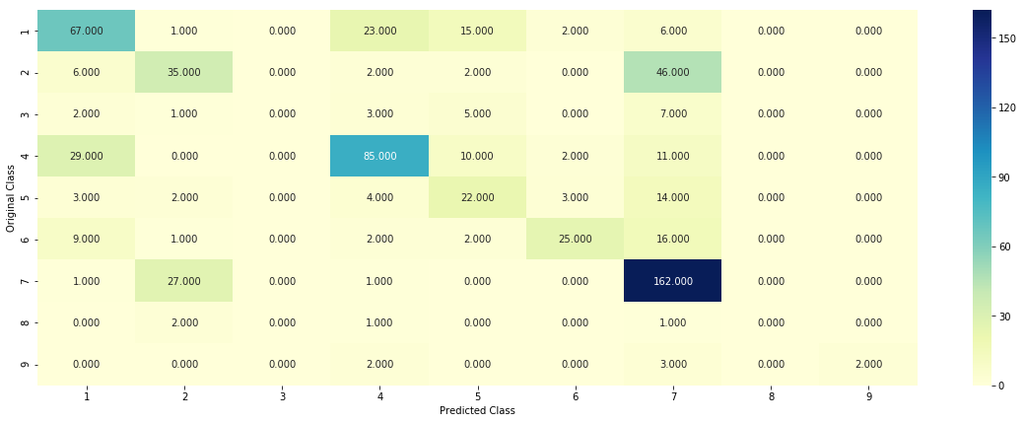

```
-------------------- Precision matrix (Columm Sum=1) --------------------
```

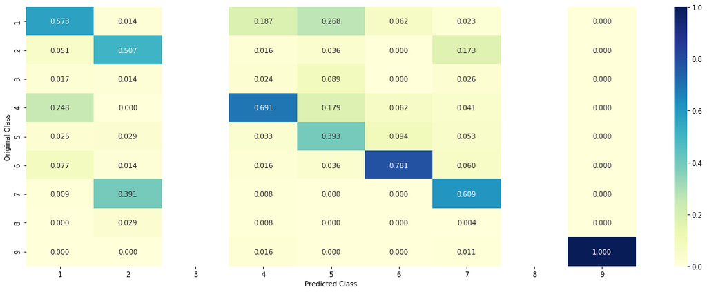

```
-------------------- Recall matrix (Row sum=1) --------------------
```

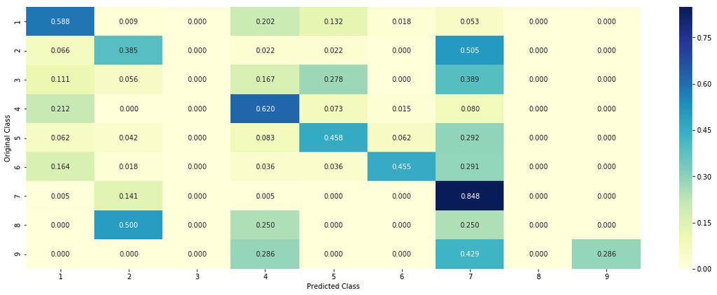

```python
lr = LogisticRegression(C=0.1)
sclf = StackingClassifier(classifiers=[sig_clf1, sig_clf2, sig_clf3], meta_classifier=lr, use_probas=True)
sclf.fit(train_x_onehotCoding, train_y)

stack_log_error_train = log_loss(train_y, sclf.predict_proba(train_x_onehotCoding))
print("Log loss (train) on the stacking classifier :",stack_log_error_train)

stack_log_error_cv = log_loss(cv_y, sclf.predict_proba(cv_x_onehotCoding))
print("Log loss (CV) on the stacking classifier :",stack_log_error_cv)

stack_log_error_test = log_loss(test_y, sclf.predict_proba(test_x_onehotCoding))
print("Log loss (test) on the stacking classifier :",stack_log_error_test)

stackmp=np.count_nonzero((sclf.predict(test_x_onehotCoding)- test_y))/test_y.shape[0]
print("Number of missclassified point :", stackmp)
plot_confusion_matrix(test_y=test_y, predict_y=sclf.predict(test_x_onehotCoding))
```

### 4.7.3 Maximum Voting classifier

```
Log loss (train) on the VotingClassifier : 0.9633631291524695
Log loss (CV) on the VotingClassifier : 0.9633631291524695
Log loss (test) on the VotingClassifier : 0.9633631291524695
Number of missclassified point : 0.3774436090225564
-------------------- Confusion matrix --------------------
```

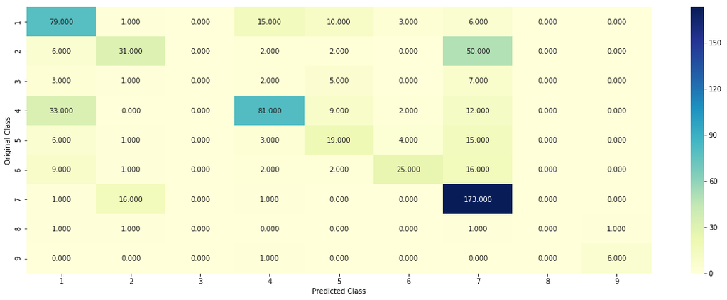

```
-------------------- Precision matrix (Columm Sum=1) --------------------
```

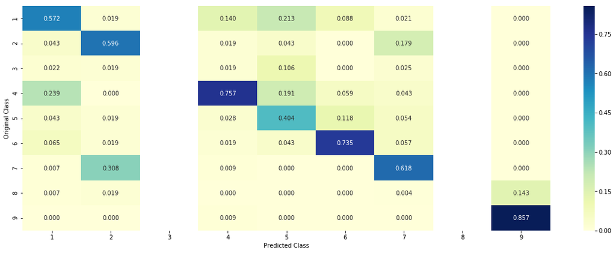

```
-------------------- Recall matrix (Row sum=1) --------------------
```

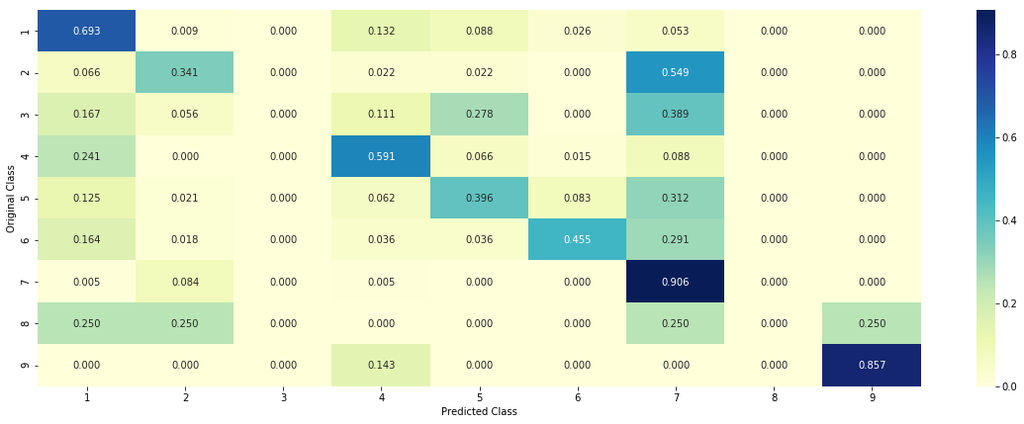

```python
#Refer:http://scikit-learn.org/stable/modules/generated/sklearn.ensemble.VotingClassifier.html
from sklearn.ensemble import VotingClassifier
vclf = VotingClassifier(estimators=[('lr', sig_clf1), ('svc', sig_clf2), ('rf', sig_clf3)], voting='soft')
vclf.fit(train_x_onehotCoding, train_y)

max_log_error_train=log_loss(train_y, vclf.predict_proba(train_x_onehotCoding))
max_log_error_cv=log_loss(cv_y, vclf.predict_proba(cv_x_onehotCoding))
max_log_error_test=log_loss(test_y, vclf.predict_proba(test_x_onehotCoding))

print("Log loss (train) on the VotingClassifier :",max_log_error_train)
print("Log loss (CV) on the VotingClassifier :",max_log_error_train)
print("Log loss (test) on the VotingClassifier :",max_log_error_train)
maxmp=np.count_nonzero((vclf.predict(test_x_onehotCoding)- test_y))/test_y.shape[0]
print("Number of missclassified point :", maxmp)
plot_confusion_matrix(test_y=test_y, predict_y=vclf.predict(test_x_onehotCoding))
```

# 5. Assignments

1. Apply All the models with tf-idf features (Replace CountVectorizer with tfidfVectorizer and run the same cells)
2. Instead of using all the words in the dataset, use only the top 1000 words based of tf-idf values
3. Apply Logistic regression with CountVectorizer Features, including both unigrams and bigrams
4. Try any of the feature engineering techniques discussed in the course to reduce the CV and test log-loss to a value less than 1.0

# 5. APPLYING FEATURE ENGG -> ONE HOT on GENE & VARIATION and TF-IDF - BIGRAM (Top 20000) on TEXT

### GENE - ONE HOT CODING

```python
# one-hot encoding of Gene feature.
gene_vectorizer_fe = CountVectorizer()
train_gene_feature_onehotCoding_fe = gene_vectorizer_fe.fit_transform(train_df['Gene'])
test_gene_feature_onehotCoding_fe = gene_vectorizer_fe.transform(test_df['Gene'])
cv_gene_feature_onehotCoding_fe = gene_vectorizer_fe.transform(cv_df['Gene'])
print('train_gene_feature_onehotCoding',train_gene_feature_onehotCoding_fe.shape)
```

```
train_gene_feature_onehotCoding (2124, 229)
```

### VARIATION - ONE HOT CODING

```python
### one-hot encoding of variation feature.
variation_vectorizer_fe = CountVectorizer()
train_variation_feature_onehotCoding_fe = variation_vectorizer_fe.fit_transform(train_df['Variation'])
test_variation_feature_onehotCoding_fe = variation_vectorizer_fe.transform(test_df['Variation'])
cv_variation_feature_onehotCoding_fe = variation_vectorizer_fe.transform(cv_df['Variation'])
```

### TEXT - TFIDF (TOP 20000) CODING

```python
# building a CountVectorizer with all the words that occured minimum 3 times in train data
## text_vectorizer = CountVectorizer(min_df=3)
text_vectorizer_fe = TfidfVectorizer(ngram_range=(2,2),min_df=3,max_features=20000)
train_text_feature_onehotCoding_fe = text_vectorizer_fe.fit_transform(train_df['TEXT'])
# getting all the feature names (words)
train_text_features= text_vectorizer_fe.get_feature_names()

# train_text_feature_onehotCoding.sum(axis=0).A1 will sum every row and returns (1*number of features) vector
train_text_fea_counts = train_text_feature_onehotCoding_fe.sum(axis=0).A1

# zip(list(text_features),text_fea_counts) will zip a word with its number of times it occured
text_fea_dict = dict(zip(list(train_text_features),train_text_fea_counts))


print("Total number of unique words in train data :", len(train_text_features))
```

```
Total number of unique words in train data : 20000
```

```python
# don't forget to normalize every feature
train_text_feature_onehotCoding_fe = normalize(train_text_feature_onehotCoding_fe, axis=0)

# we use the same vectorizer that was trained on train data
test_text_feature_onehotCoding_fe = text_vectorizer_fe.transform(test_df['TEXT'])
# don't forget to normalize every feature
test_text_feature_onehotCoding_fe = normalize(test_text_feature_onehotCoding_fe, axis=0)

# we use the same vectorizer that was trained on train data
cv_text_feature_onehotCoding_fe = text_vectorizer_fe.transform(cv_df['TEXT'])
# don't forget to normalize every feature
cv_text_feature_onehotCoding_fe = normalize(cv_text_feature_onehotCoding_fe, axis=0)
```

```python
## for count vectorizer
train_x_onehotCoding_count_fe = hstack((train_gene_feature_onehotCoding_fe,train_variation_feature_onehotCoding_fe, train_text_feature_onehotCoding_fe)).tocsr()
test_x_onehotCoding_count_fe = hstack((test_gene_feature_onehotCoding_fe,test_variation_feature_onehotCoding_fe, test_text_feature_onehotCoding_fe)).tocsr()
cv_x_onehotCoding_count_fe = hstack((cv_gene_feature_onehotCoding_fe,cv_variation_feature_onehotCoding_fe, cv_text_feature_onehotCoding_fe)).tocsr()
```

```python
print("One hot encoding features :")
print("(number of data points * number of features) in train data = ", train_x_onehotCoding_count_fe.shape)
print("(number of data points * number of features) in test data = ", test_x_onehotCoding_count_fe.shape)
print("(number of data points * number of features) in cross validation data =", cv_x_onehotCoding_count_fe.shape)
```

```
One hot encoding features :
(number of data points * number of features) in train data =  (2124, 22183)
(number of data points * number of features) in test data =  (665, 22183)
(number of data points * number of features) in cross validation data = (532, 22183)
```

### With Class balancing

#### Hyper paramter tuning

```
for alpha = 1e-06
Log Loss : 1.2849979023287197
for alpha = 1e-05
Log Loss : 1.2712414218818369
for alpha = 0.0001
Log Loss : 1.1346454367296734
for alpha = 0.001
Log Loss : 1.1294924015284218
for alpha = 0.01
Log Loss : 1.1849629766515126
for alpha = 0.1
Log Loss : 1.350325952443423
for alpha = 1
Log Loss : 1.4864088418630865
for alpha = 10
Log Loss : 1.5092245753406153
for alpha = 100
Log Loss : 1.5119242455239816
```

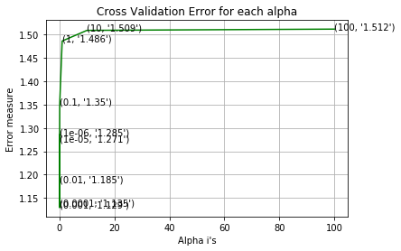

```
For values of best alpha =  0.001 The train log loss is: 0.5289714669249315
For values of best alpha =  0.001 The cross validation log loss is: 1.1294924015284218
For values of best alpha =  0.001 The test log loss is: 1.0532609109841884
```

```python
alpha = [10 ** x for x in range(-6, 3)]
cv_log_error_array = []
for i in alpha:
    print("for alpha =", i)
    clf = SGDClassifier(class_weight='balanced', alpha=i, penalty='l2', loss='log', random_state=42)
    clf.fit(train_x_onehotCoding_count_fe, train_y)
    sig_clf = CalibratedClassifierCV(clf, method="sigmoid")
    sig_clf.fit(train_x_onehotCoding_count_fe, train_y)
    sig_clf_probs = sig_clf.predict_proba(cv_x_onehotCoding_count_fe)
    cv_log_error_array.append(log_loss(cv_y, sig_clf_probs, labels=clf.classes_, eps=1e-15))
    # to avoid rounding error while multiplying probabilites we use log-probability estimates
    print("Log Loss :",log_loss(cv_y, sig_clf_probs))

fig, ax = plt.subplots()
ax.plot(alpha, cv_log_error_array,c='g')
for i, txt in enumerate(np.round(cv_log_error_array,3)):
    ax.annotate((alpha[i],str(txt)), (alpha[i],cv_log_error_array[i]))
plt.grid()
plt.title("Cross Validation Error for each alpha")
plt.xlabel("Alpha i's")
plt.ylabel("Error measure")
plt.show()


best_alpha = np.argmin(cv_log_error_array)
clf = SGDClassifier(class_weight='balanced', alpha=alpha[best_alpha], penalty='l2', loss='log', random_state=42)
clf.fit(train_x_onehotCoding_count_fe, train_y)
sig_clf = CalibratedClassifierCV(clf, method="sigmoid")
sig_clf.fit(train_x_onehotCoding_count_fe, train_y)

predict_y = sig_clf.predict_proba(train_x_onehotCoding_count_fe)
lrLossClassBalance_tfidf_train_fe=log_loss(y_train, predict_y, labels=clf.classes_, eps=1e-15)
print('For values of best alpha = ', alpha[best_alpha], "The train log loss is:",lrLossClassBalance_tfidf_train_fe)

predict_y = sig_clf.predict_proba(cv_x_onehotCoding_count_fe)
lrLossClassBalance_tfidf_cv_fe=log_loss(y_cv, predict_y, labels=clf.classes_, eps=1e-15)
print('For values of best alpha = ', alpha[best_alpha], "The cross validation log loss is:",lrLossClassBalance_tfidf_cv_fe)

predict_y = sig_clf.predict_proba(test_x_onehotCoding_count_fe)
lrLossClassBalance_tfidf_test_fe=log_loss(y_test, predict_y, labels=clf.classes_, eps=1e-15)
print('For values of best alpha = ', alpha[best_alpha], "The test log loss is:",lrLossClassBalance_tfidf_test_fe)
```

```python
print("lrLossClassBalance_tfidf_train",lrLossClassBalance_tfidf_train_fe)
print("lrLossClassBalance_tfidf_cv",lrLossClassBalance_tfidf_cv_fe)
print("lrLossClassBalance_tfidf_test",lrLossClassBalance_tfidf_test_fe)
```

```
lrLossClassBalance_tfidf_train 0.5289714669249315
lrLossClassBalance_tfidf_cv 1.1294924015284218
lrLossClassBalance_tfidf_test 1.0532609109841884
```

#### 4.3.1.2. Testing the model with best hyper paramters

```
Log loss : 1.1294924015284218
Number of mis-classified points : 0.35150375939849626
-------------------- Confusion matrix --------------------
```

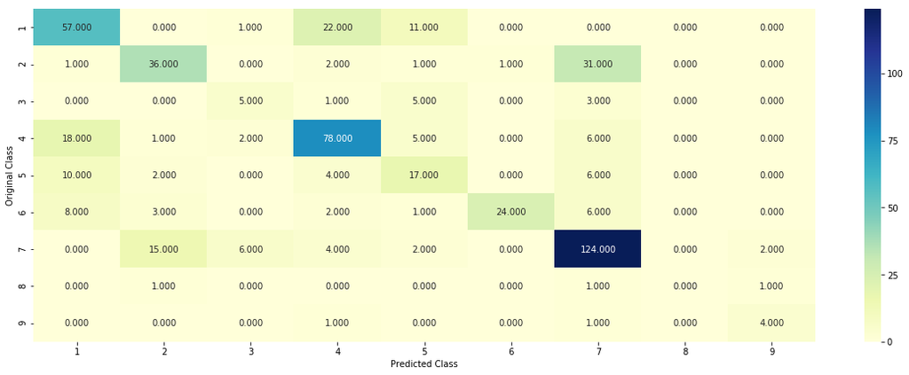

```
-------------------- Precision matrix (Columm Sum=1) --------------------
```

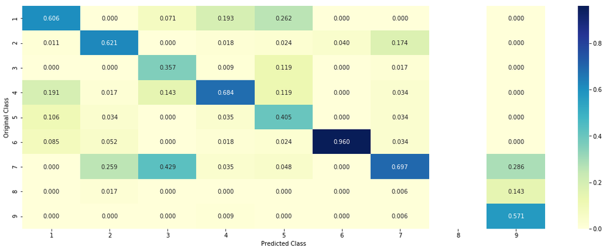

```
-------------------- Recall matrix (Row sum=1) --------------------
```

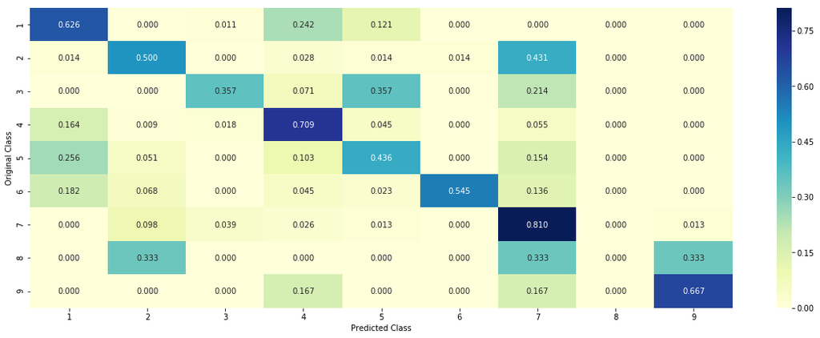

```python
clf = SGDClassifier(class_weight='balanced', alpha=alpha[best_alpha], penalty='l2', loss='log', random_state=42)
lrClassBalancemp_fe=predict_and_plot_confusion_matrix(train_x_onehotCoding_count_fe, train_y, cv_x_onehotCoding_count_fe, cv_y, clf)
```

```python
from prettytable import PrettyTable
# Names of models
model=['Naive Bayes ','KNN','Logistic Regression With Class balancing '
       ,'LogisticRegression Without Class balancing','Linear SVM '
       ,'Random Forest Classifier With One hot Encoding'
       ,'Stack Models:LR+NB+SVM','Maximum Voting classifier'
       ,'LR(BALANCED): CountVectorizer Features, including both unigrams and bigrams','LR(UNBALANCED): CountVectorizer Features, including both unigrams and bigrams'
       ,'LR: after feature engineering']
train =[
    nbLoss_train,
    knnLoss_train,
    lrLossClassBalance_tfidf_train,
    lrLossWithoutClassBalance_tfidf_train,
    svmLoss_train,
    rfLoss_train,
    stack_log_error_train,
    max_log_error_train,
    lrLossClassBalance_count_train,
    lrLossWithoutClassBalance_count_train,
    lrLossClassBalance_tfidf_train_fe]
cv=[
    nbLoss_cv,
    knnLoss_cv,
    lrLossClassBalance_tfidf_cv,
    lrLossWithoutClassBalance_tfidf_cv,
    svmLoss_cv,
    rfLoss_cv,
    stack_log_error_cv,
    max_log_error_cv,
    lrLossClassBalance_count_cv,
    lrLossWithoutClassBalance_count_cv,
    lrLossClassBalance_tfidf_cv_fe
]
test = [
    nbLoss_test,
    knnLoss_test,
    lrLossClassBalance_tfidf_test,
    lrLossWithoutClassBalance_tfidf_test,
    svmLoss_test,
    rfLoss_test,
    stack_log_error_test,
    max_log_error_test,
    lrLossClassBalance_count_test,
    lrLossWithoutClassBalance_count_test,
    lrLossClassBalance_tfidf_test_fe,
]

mp=[
    nbmp,
    knnmp,
    lrClassBalancemp,
    lrWithoutClassBalancemp,
    svmmp,
    rfmp,
    stackmp,
    maxmp,
    lrClassBalanceCountmp,
    lrWithoutClassBalanceCountmp,
    lrClassBalancemp_fe,
   ]


train=[round(x,2) for x in train]
cv=[round(x,2) for x in cv]
test=[round(x,2) for x in test]
mp=[round(x,2) for x in mp]
numbering=[1,2,3,4,5,6,7,8,9,10,11]
# Initializing prettytable
ptable = PrettyTable()
# Adding columns
ptable.add_column("S.NO.",numbering)
ptable.add_column("model",model)
ptable.add_column("train",train)
ptable.add_column("cv",cv)
ptable.add_column("test",test)
ptable.add_column("% Missclassified Points",mp)
# Printing the Table
print(ptable)
```

[output not shown]

**CONCLUSION**

1. Thus we can see that Logistic Regression is the best compared to all the models.
2. Our model with BOW on GENE & VARIATION and with TFIDF (TOP 20000 BIGRAM) performs the second best with LogLoss of TEST and CV very very close to 1.